# Efficacy of Adjuvant Chemotherapy (5-FU + Levamisole) in Stage II/III Colon Cancer

Phase III Randomized Clinical Trial

Abderrezzaq KADOUCHE

## **Study Context**

This dataset originates from a landmark multi-center, randomized Phase III trial conducted by the *NCCTG* and the *Mayo Clinic* (Moertel et al., 1991). It evaluates the efficacy of two post-surgery adjuvant therapies against an observation control group for patients with resected stage II/III colon carcinoma:

* **Levamisole:** A low-toxicity compound historically used as an animal anti-worm agent.

* **5-Fluorouracil (5-FU):** A moderately toxic antimetabolite chemotherapy.

The data features a multivariate failure time structure with two records per patient to track sequential clinical endpoints: recurrence and death.

It also includes a known real-world data inconsistency between the lymph node count (`nodes`) and its binary threshold (`node4`).

## **Aim**

The primary objective of this statistical analysis is to determine whether adjuvant chemotherapy combining Levamisole and 5-Fluorouracil significantly prolongs time-to-event outcomes compared to Levamisole alone or simple observation in patients with resected Stage B/C colon cancer.

## **Variable Labels**

The variables are defined and coded as follows:

- **`id`** | Patient identifier (numeric)
- **`study`** | Study code (coded as `1` for all patients)
- **`rx`** | Treatment allocation group:
  - `Obs`: Observation (Control arm)
  - `Lev`: Levamisole mono-therapy
  - `Lev+5FU`: Combined Levamisole and 5-Fluorouracil therapy
- **`sex`** | Patient biological sex (`1` = Male, `0` = Female)
- **`age`** | Patient age at study registration (in years)
- **`obstruct`** | Obstruction of the colon by the tumor (`1` = Yes, `0` = No)
- **`perfor`** | Perforation of the colon by the tumor (`1` = Yes, `0` = No)
- **`adhere`** | Tumor adherence to nearby organs (`1` = Yes, `0` = No)
- **`nodes`** | Total number of regional lymph nodes with detectable cancer (integer)
- **`time`** | Follow-up duration: Days until the clinical event occurred or until right-censoring
- **`status`** | Censoring indicator for the specific event type (`1` = Event occurred, `0` = Censored / Lost to follow-up)
- **`differ`** | Histological differentiation grade of the tumor:
  - `1`: Well differentiated
  - `2`: Moderately differentiated
  - `3`: Poorly differentiated
- **`extent`** | Extent of local anatomical tumor spread:
  - `1`: Submucosa
  - `2`: Muscle
  - `3`: Serosa
  - `4`: Contiguous structures
- **`surg`** | Time elapsed from surgical resection to study registration (`0` = Short interval, `1` = Long interval)
- **`node4`** | Indicator of heavy nodal involvement (`1` = More than 4 positive lymph nodes, `0` = 4 or fewer)
- **`etype`** | Clinical event type tracked in the row (`1` = Disease recurrence, `2` = Death)

```r
# Si vous analysez la récidive :
data_recurrence <- subset(colon, etype == 1)

# Si vous analysez le décès :
data_death <- subset(colon, etype == 2)
```

## **Descriptive Analysis of Continuous Variables**

```r
library(prettyR)

vars_quanti <- c("age", "nodes")

describe(
  data_recurrence[, vars_quanti],
  num.desc = c("min", "max", "mean", "median", "sd", "valid.n")
)
```

```
## Description of data_recurrence[, vars_quanti]
```

```
##
##  Numeric
##       min max  mean median    sd valid.n
## age    18  85 59.75     61 11.95     929
## nodes   0  33  3.66      2  3.57     911
```

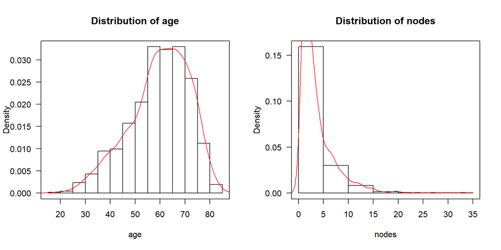

```r
par(mfrow = c(1, 2))


# Boucle sur toutes les variables quantitatives avec courbe de densité
for (var in vars_quanti) {

  # 1. Tracer l'histogramme en mode "densité de probabilité" (prob = TRUE)
  hist(data_recurrence[[var]],
       main = paste("Distribution of", var), # Titre dynamique
       xlab = var,                           # Nom de la variable sur l'axe X
       ylab = "Density",                     # L'axe Y devient la Densité
       las  = 1,  # Labels horizontaux
       col  = "white",                       # Barres blanches
       border = "black",                     # Contours noirs
       prob = TRUE)                          # OBLIGATOIRE pour la densité

  # 2. Calculer et superposer la courbe de densité
  # na.rm = TRUE est crucial car il peut y avoir des NA dans la colonne 'nodes'
  lines(density(data_recurrence[[var]], na.rm = TRUE),
        col = "red",                         # Courbe en rouge pour le contraste
        lwd = 1)                             # Épaisseur de la ligne

# 3. AJOUT DU CADRE AUTOUR DU GRAPHIQUE
box(col = "black", lwd = 1)
}
```

## **Descriptive Analysis of Categorical Variables**

```r
library(gtsummary)

library(dplyr)


data_recurrence %>%
  select(rx, sex, obstruct, perfor, adhere, differ, extent, surg) %>%
  tbl_summary(
    by = rx,
    # 1. Forcer R à traiter les chiffres (0,1,2..) comme des catégories
    type = list(
      sex      ~ "categorical",
      obstruct ~ "categorical",
      perfor   ~ "categorical",
      adhere   ~ "categorical",
      differ   ~ "categorical",
      extent   ~ "categorical",
      surg     ~ "categorical"
    ),
    statistic = all_categorical() ~ "{n} ({p}%)",
    digits    = all_categorical() ~ list(0, 1),
    # 2. Spécification directe des étiquettes (avec rappel du codage entre parenthèses)
    label     = list(
      sex      ~ "Sex (1 = Male, 0 = Female)",
      obstruct ~ "Colon obstruction (1 = Yes)",
      perfor   ~ "Colon perforation (1 = Yes)",
      adhere   ~ "Adherence to nearby organs (1 = Yes)",
      differ   ~ "Tumor differentiation (1=Well, 2=Moderate, 3=Poor)",
      extent   ~ "Extent of local spread (1 to 4)",
      surg     ~ "Time from surgery to registration (1 = Long)"
    ),
    missing_text = "Missing"
  ) %>%
  bold_labels()
```

| **Characteristic** | **Obs** N = 315<sup>1</sup> | **Lev** N = 310<sup>1</sup> | **Lev+5FU** N = 304<sup>1</sup> |
| --- | --- | --- | --- |
| Sex (1 = Male, 0 = Female) |  |  |  |
| 0 | 149 (47.3%) | 133 (42.9%) | 163 (53.6%) |
| 1 | 166 (52.7%) | 177 (57.1%) | 141 (46.4%) |
| Colon obstruction (1 = Yes) |  |  |  |
| 0 | 252 (80.0%) | 247 (79.7%) | 250 (82.2%) |
| 1 | 63 (20.0%) | 63 (20.3%) | 54 (17.8%) |
| Colon perforation (1 = Yes) |  |  |  |
| 0 | 306 (97.1%) | 300 (96.8%) | 296 (97.4%) |
| 1 | 9 (2.9%) | 10 (3.2%) | 8 (2.6%) |
| Adherence to nearby organs (1 = Yes) |  |  |  |
| 0 | 268 (85.1%) | 261 (84.2%) | 265 (87.2%) |
| 1 | 47 (14.9%) | 49 (15.8%) | 39 (12.8%) |
| Tumor differentiation (1=Well, 2=Moderate, 3=Poor) |  |  |  |
| 1 | 27 (8.8%) | 37 (12.3%) | 29 (9.7%) |
| 2 | 229 (74.4%) | 219 (73.0%) | 215 (72.1%) |
| 3 | 52 (16.9%) | 44 (14.7%) | 54 (18.1%) |
| Missing | 7 | 10 | 6 |
| Extent of local spread (1 to 4) |  |  |  |
| 1 | 8 (2.5%) | 3 (1.0%) | 10 (3.3%) |
| 2 | 38 (12.1%) | 36 (11.6%) | 32 (10.5%) |
| 3 | 249 (79.0%) | 259 (83.5%) | 251 (82.6%) |
| 4 | 20 (6.3%) | 12 (3.9%) | 11 (3.6%) |
| Time from surgery to registration (1 = Long) |  |  |  |
| 0 | 224 (71.1%) | 230 (74.2%) | 228 (75.0%) |
| 1 | 91 (28.9%) | 80 (25.8%) | 76 (25.0%) |

<sup>1</sup> n (%)

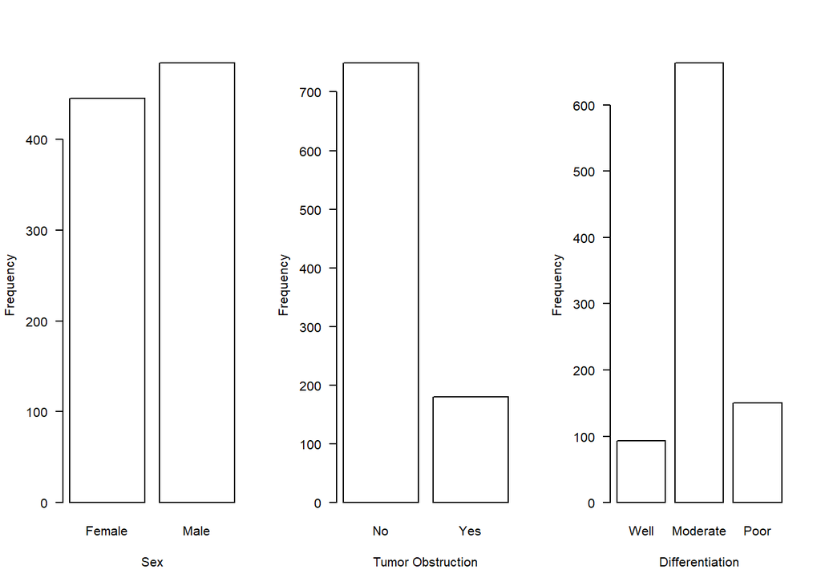

```r
# Configuration de la zone graphique : 1 ligne, 3 colonnes pour aligner les 3 graphiques
par(mfrow = c(1, 3))

# ── 1. SEX (Sexe) ──────────────────────────────────────
barplot(
  table(data_recurrence$sex),
  ylab      = "Frequency",
  xlab      = "Sex",
  names.arg = c("Female", "Male"), # Le package code 0=Female, 1=Male
  col       = "white",
  border    = "black",
  las       = 1,
  cex.names = 1.0,
  cex.lab   = 1.0
)

# ── 2. OBSTRUCTION (Obstruction de la tumeur) ───────────
barplot(
  table(data_recurrence$obstruct),
  ylab      = "Frequency",
  xlab      = "Tumor Obstruction",
  names.arg = c("No", "Yes"), # Le package code 0=No, 1=Yes
  col       = "white",
  border    = "black",
  las       = 1,
  cex.names = 1.0,
  cex.lab   = 1.0
)

# ── 3. DIFFERENTIATION (Différenciation) ───────────────
barplot(
  table(data_recurrence$differ),
  ylab      = "Frequency",
  xlab      = "Differentiation",
  names.arg = c("Well", "Moderate", "Poor"), # Le package code 1=Well, 2=Moderate, 3=Poor
  col       = "white",
  border    = "black",
  las       = 1,
  cex.names = 1.0,
  cex.lab   = 1.0
)
```

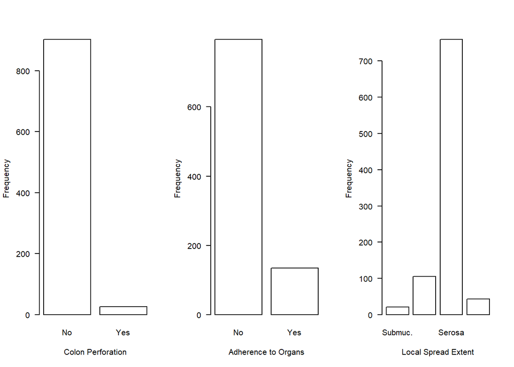

```r
# Variables cliniques et anatomopathologiques (1 ligne, 3 colonnes)


# ── 1. PERFORATION (Colon perforation) ─────────────────
barplot(
  table(data_recurrence$perfor),
  ylab      = "Frequency",
  xlab      = "Colon Perforation",
  names.arg = c("No", "Yes"), # 0 = No, 1 = Yes
  col       = "white",
  border    = "black",
  las       = 1
)

# ── 2. ADHERENCE (Adherence to nearby organs) ──────────
barplot(
  table(data_recurrence$adhere),
  ylab      = "Frequency",
  xlab      = "Adherence to Organs",
  names.arg = c("No", "Yes"), # 0 = No, 1 = Yes
  col       = "white",
  border    = "black",
  las       = 1
)

# ── 3. EXTENT (Extent of local spread) ─────────────────
barplot(
  table(data_recurrence$extent),
  ylab      = "Frequency",
  xlab      = "Local Spread Extent",
  names.arg = c("Submuc.", "Muscle", "Serosa", "Contig."), # 1 to 4
  col       = "white",
  border    = "black",
  las       = 1
)
```

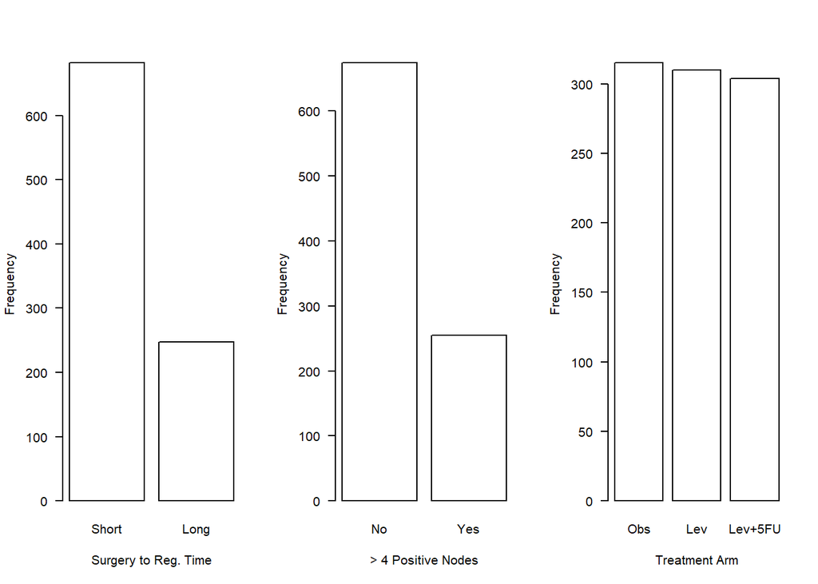

```r
#Variables de prise en charge et de traitement (1 ligne, 3 colonnes)

# ── 4. SURG (Time from surgery to registration) ────────
barplot(
  table(data_recurrence$surg),
  ylab      = "Frequency",
  xlab      = "Surgery to Reg. Time",
  names.arg = c("Short", "Long"), # 0 = Short, 1 = Long
  col       = "white",
  border    = "black",
  las       = 1
)

# ── 5. NODE4 (More than 4 positive lymph nodes) ────────
barplot(
  table(data_recurrence$node4),
  ylab      = "Frequency",
  xlab      = "> 4 Positive Nodes",
  names.arg = c("No", "Yes"), # 0 = 4 or less, 1 = More than 4
  col       = "white",
  border    = "black",
  las       = 1
)

# ── 6. RX (Treatment allocation) ───────────────────────
barplot(
  table(data_recurrence$rx),
  ylab      = "Frequency",
  xlab      = "Treatment Arm",
  # Pas besoin de names.arg car les étiquettes textuelles (Obs, Lev, Lev+5FU)
  # sont déjà nativement présentes dans la variable
  col       = "white",
  border    = "black",
  las       = 1
)
```

## **Missing data**

Missing data is limited to **`differ`** (2.48%) which is the histological differentiation grade of the tumor and **`nodes`** (1.94%) which is the total number of regional lymph nodes with detectable cancer.

To address this low missingness rate, a complete-case analysis will be applied.

```r
tab_NA <- data.frame(
  Variables = names(data_recurrence),
  n_NA = colSums(is.na(data_recurrence)),
  percent_NA = round(colMeans(is.na(data_recurrence)) * 100, 2),
  row.names = NULL )

print(tab_NA)
```

```
##    Variables n_NA percent_NA
## 1         id    0       0.00
## 2      study    0       0.00
## 3         rx    0       0.00
## 4        sex    0       0.00
## 5        age    0       0.00
## 6   obstruct    0       0.00
## 7     perfor    0       0.00
## 8     adhere    0       0.00
## 9      nodes   18       1.94
## 10    status    0       0.00
## 11    differ   23       2.48
## 12    extent    0       0.00
## 13      surg    0       0.00
## 14     node4    0       0.00
## 15      time    0       0.00
## 16     etype    0       0.00
```

## **Kaplan-Meier Curves**

Censoring is assumed to be non-informative.

The **Log-Rank test** reveals :

- a significant difference in disease-free survival between the treatment groups (p < 0.0001). We conclude that treatment allocation significantly impacts the time to cancer recurrence.
- a significant difference in overall survival between the treatment groups (p = 0.0029). We conclude that treatment allocation significantly impacts the time to death.

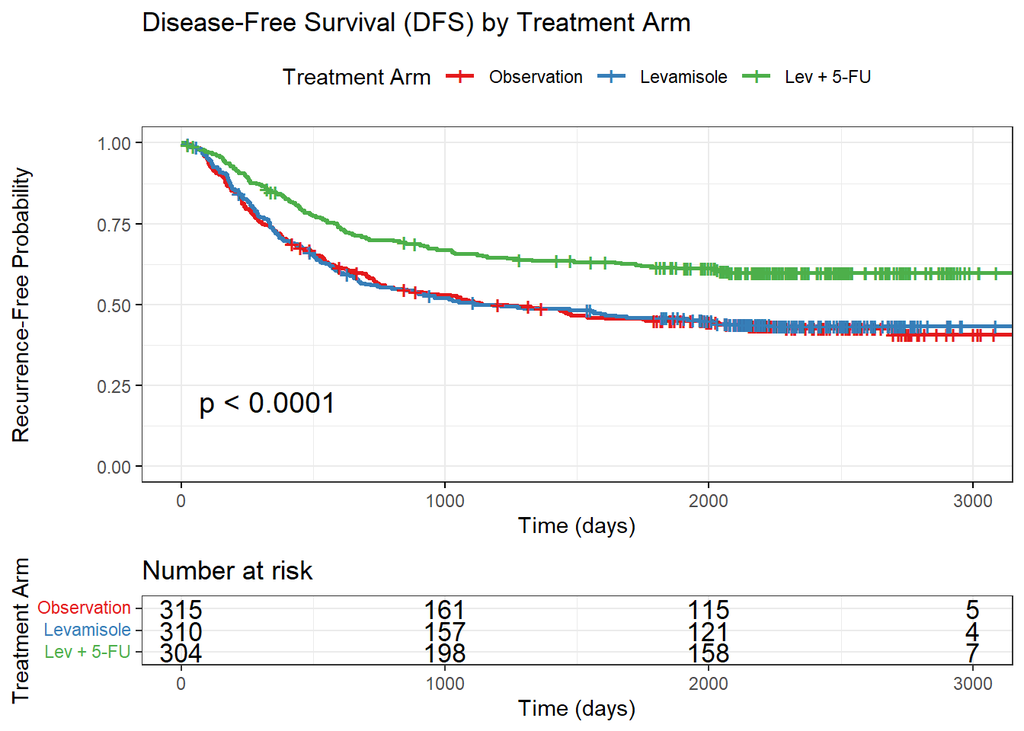

```r
library(survival)

library(survminer)

library(tidyverse)

# 1. Ajustement du modèle de Kaplan-Meier pour la Récidive par bras de traitement (rx)
fit_recurrence <- survfit(Surv(time = time, event = status) ~ rx, data = data_recurrence)

# 2. Tracé des courbes de survie sans récidive
ggsurvplot(
  fit_recurrence,
  data             = data_recurrence,
  conf.int         = FALSE, # Recommandé à FALSE pour 3 courbes pour éviter les chevauchements visuels
  pval             = TRUE,
  risk.table       = TRUE,
  ggtheme          = theme_bw(), # Cadre noir complet et épuré
  legend.title     = "Treatment Arm",
  xlab             = "Time (days)",
  ylab             = "Recurrence-Free Probability",
  legend.labs      = c("Observation", "Levamisole", "Lev + 5-FU"),
  palette          = c("#E41A1C", "#377EB8", "#4DAF4A"), # Couleurs  bien distinctes
  risk.table.title = "Number at risk",
  title            = "Disease-Free Survival (DFS) by Treatment Arm"
)
```

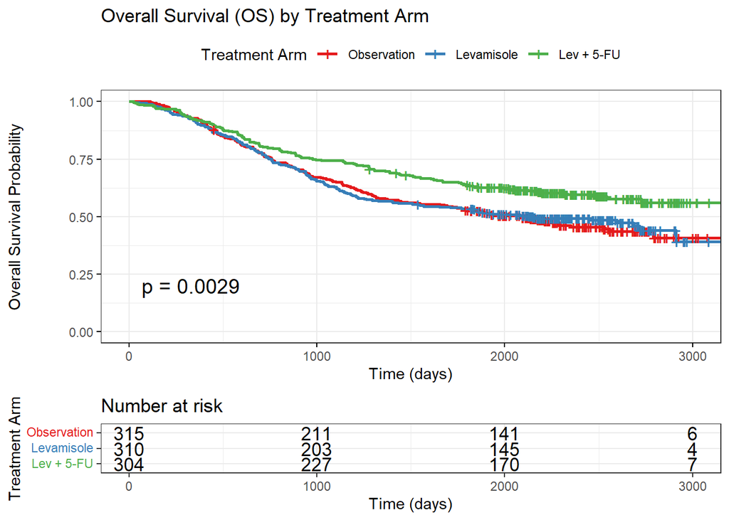

```r
# 1. Ajustement du modèle de Kaplan-Meier pour le Décès par bras de traitement (rx)
fit_death <- survfit(Surv(time = time, event = status) ~ rx, data = data_death)

# 2. Tracé des courbes de survie globale
ggsurvplot(
  fit_death,
  data             = data_death,
  conf.int         = FALSE,
  pval             = TRUE,
  risk.table       = TRUE,
  ggtheme          = theme_bw(),
  legend.title     = "Treatment Arm",
  xlab             = "Time (days)",
  ylab             = "Overall Survival Probability",
  legend.labs      = c("Observation", "Levamisole", "Lev + 5-FU"),
  palette          = c("#E41A1C", "#377EB8", "#4DAF4A"),
  risk.table.title = "Number at risk",
  title            = "Overall Survival (OS) by Treatment Arm"
)
```

## **Median survival**

In the levamisole plus 5-FU group, the median times for both recurrence-free survival and overall survival were not reached. For both endpoints, more than 50% of the patients remained alive and free of disease recurrence at the end of the follow-up period.

```r
surv_median(fit_recurrence)
```

```
##       strata median lower upper
## 1     rx=Obs   1236   803  2036
## 2     rx=Lev   1183   797  2067
## 3 rx=Lev+5FU     NA    NA    NA
```

```r
surv_median(fit_death)
```

```
##       strata median lower upper
## 1     rx=Obs   2083  1656  2789
## 2     rx=Lev   2152  1540    NA
## 3 rx=Lev+5FU     NA  2725    NA
```

## **Checking the proportional hazards assumption**

## **I.Recurrence**

After stratifying the model by histological differentiation grade (differ), heavy nodal involvement (node4), and bowel obstruction (obstruct), the proportional hazards assumption was successfully met. The updated Schoenfeld residual tests yielded a non-significant global test (χ² = 6.97, df = 9, p = 0.64), and no remaining covariates violated the proportionality assumption (all p > 0.05), confirming the validity of the final multivariate model.”

```r
cox_recurrence <-coxph(Surv(time, status) ~ rx +sex+age+obstruct+perfor+adhere+nodes+node4+differ+extent+surg, data = data_recurrence)

cox.zph(cox_recurrence) #test de Schoenfeld
```

```
##             chisq df       p
## rx        0.35805  2 0.83608
## sex       2.04532  1 0.15268
## age       0.00246  1 0.96046
## obstruct  5.36040  1 0.02060
## perfor    0.02471  1 0.87509
## adhere    0.74073  1 0.38943
## nodes     2.47895  1 0.11538
## node4     9.45001  1 0.00211
## differ   12.91735  1 0.00033
## extent    0.20903  1 0.64753
## surg      1.85897  1 0.17274
## GLOBAL   35.50321 12 0.00039
```

```r
cox_recurrence2 <-coxph(Surv(time, status) ~ rx +sex+age+strata(obstruct)+perfor+adhere+nodes+strata(node4)+strata(differ)+extent+surg, data = data_recurrence)

cox.zph(cox_recurrence2) #test de Schoenfeld
```

```
##         chisq df    p
## rx     0.6234  2 0.73
## sex    1.3914  1 0.24
## age    0.3663  1 0.55
## perfor 0.0911  1 0.76
## adhere 1.8064  1 0.18
## nodes  0.5977  1 0.44
## extent 0.0353  1 0.85
## surg   1.7136  1 0.19
## GLOBAL 6.9695  9 0.64
```

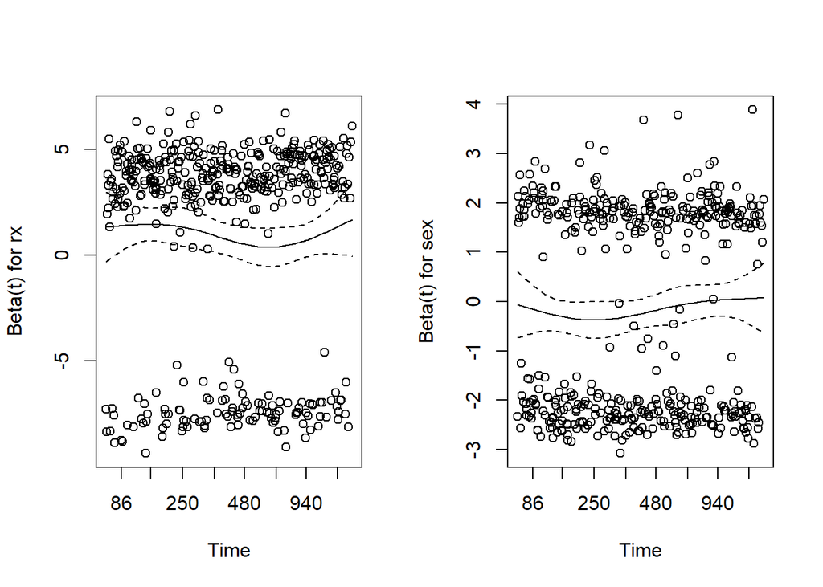

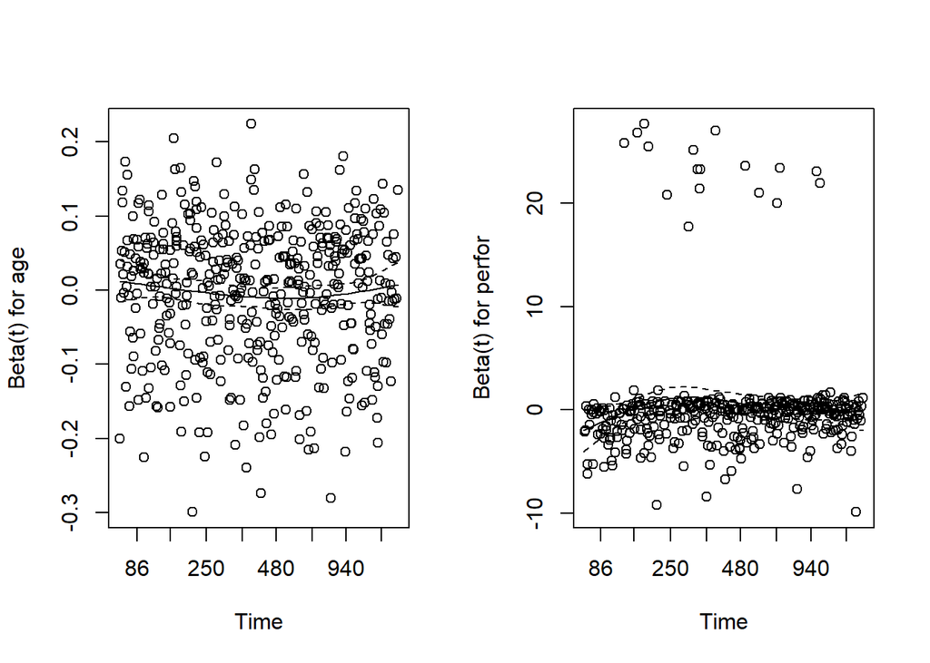

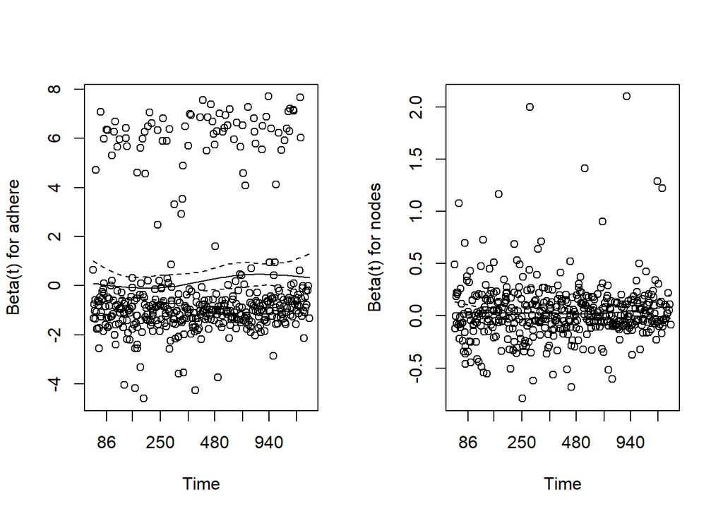

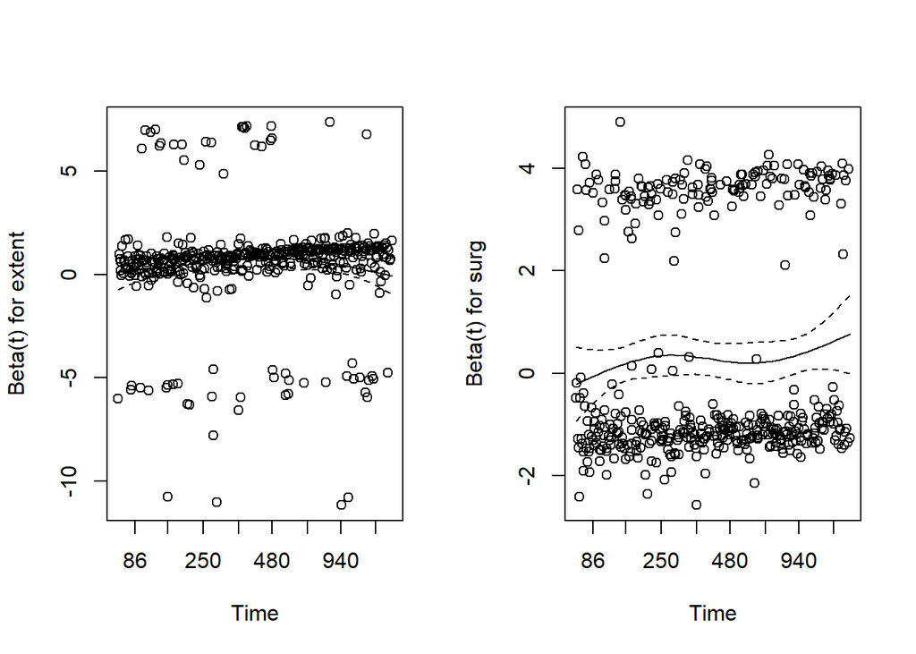

```r
par(mfrow=c(1,2))

plot(cox.zph(cox_recurrence2))
```

## **II.Death**

```r
cox_death <-coxph(Surv(time, status) ~ rx +sex+age+obstruct+perfor+adhere+nodes+node4+differ+extent+surg, data = data_death)

cox.zph(cox_death) #test de Schoenfeld
```

```
##            chisq df       p
## rx        2.8302  2 0.24290
## sex       0.1375  1 0.71074
## age       0.9306  1 0.33470
## obstruct  6.5556  1 0.01046
## perfor    0.6703  1 0.41294
## adhere    0.0198  1 0.88815
## nodes     0.3787  1 0.53831
## node4     4.7494  1 0.02931
## differ   13.2497  1 0.00027
## extent    4.1445  1 0.04177
## surg      0.0043  1 0.94771
## GLOBAL   37.6124 12 0.00018
```

```r
cox_death2 <-coxph(Surv(time, status) ~ rx +sex+age+strata(obstruct)+perfor+adhere+nodes+strata(node4)+strata(differ)+strata(extent)+surg, data = data_death)

cox.zph(cox_death2) #test de Schoenfeld
```

```
##           chisq df    p
## rx      4.14527  2 0.13
## sex     0.00012  1 0.99
## age     1.97684  1 0.16
## perfor  1.87486  1 0.17
## adhere  1.15887  1 0.28
## nodes   2.05772  1 0.15
## surg    0.00180  1 0.97
## GLOBAL 10.97781  8 0.20
```

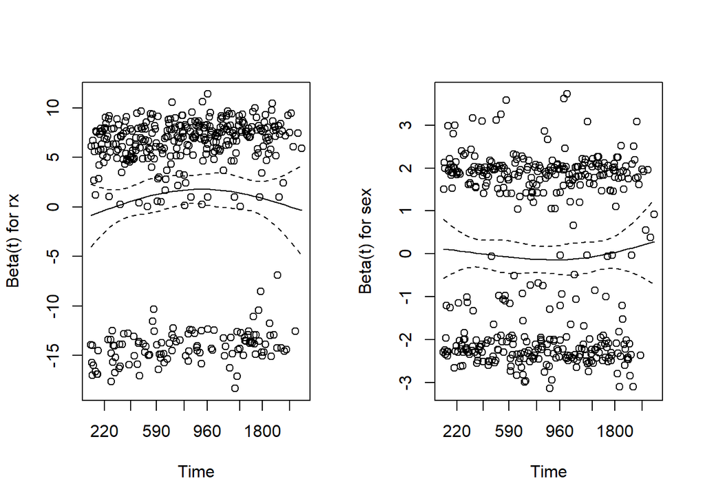

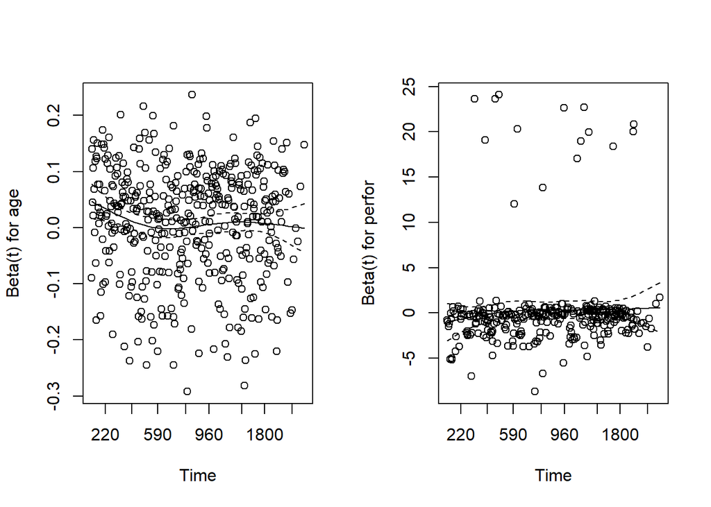

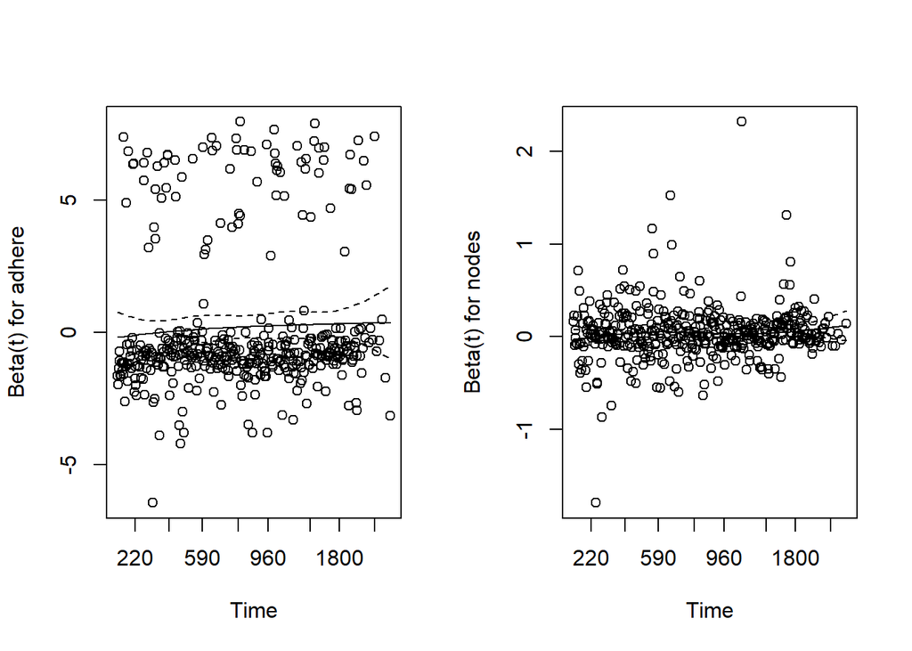

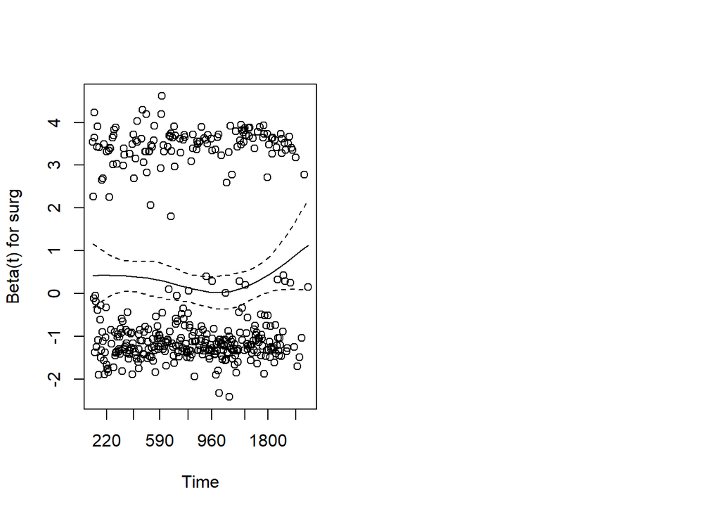

```r
par(mfrow=c(1,2))

plot(cox.zph(cox_death2))
```

## **Checking the linearity assumption**

## I.Recurrence

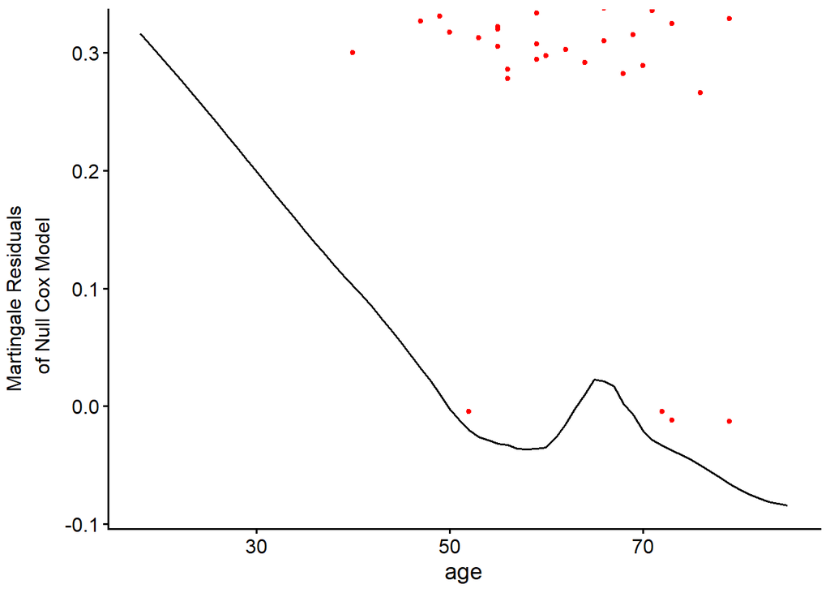

```r
ggcoxfunctional(fit_age, data = data_recurrence)
```

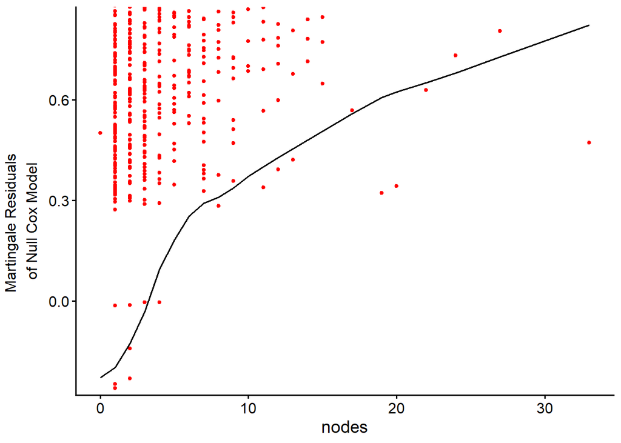

```r
ggcoxfunctional(fit_nodes, data = data_clean)
```

## II.Death

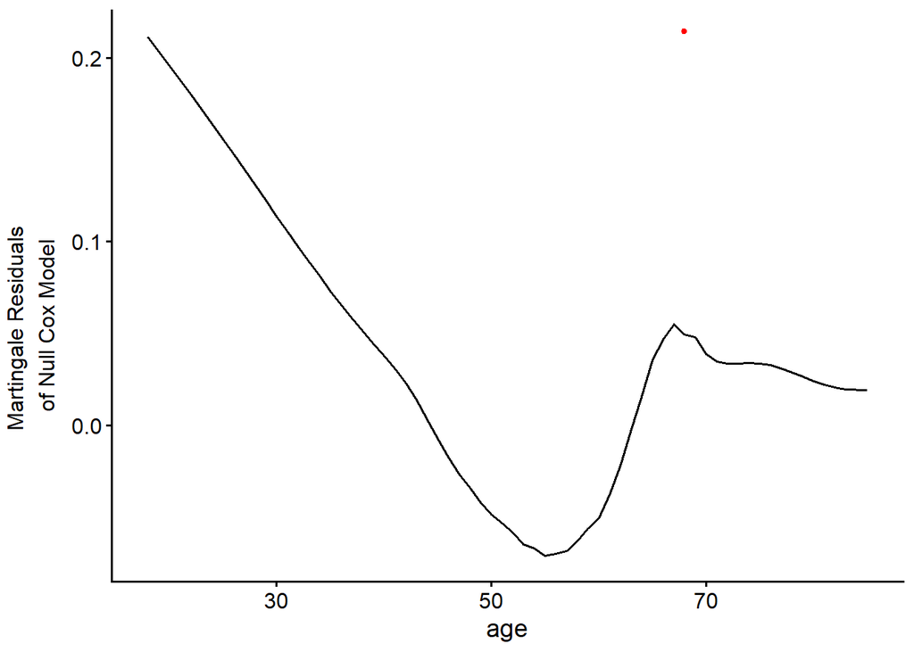

```r
ggcoxfunctional(fit_age2, data = data_death)
```

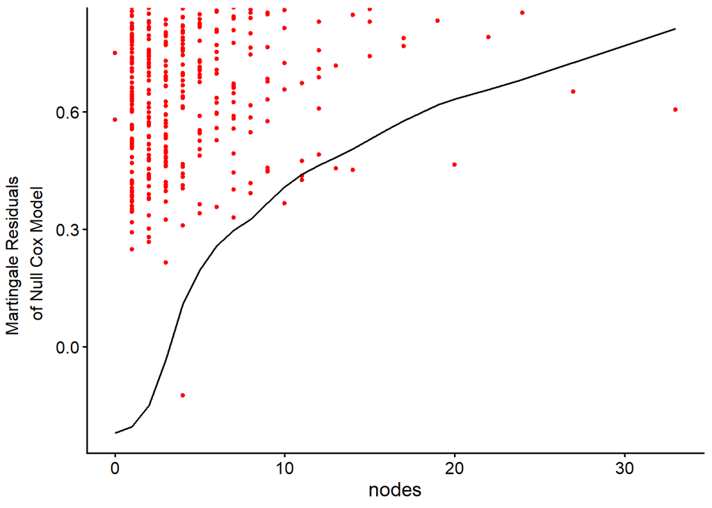

```r
ggcoxfunctional(fit_nodes2, data = data_clean)
```

# **Results**

## I.Recurrence

```r
# Modifie le nom directement sur la même ligne de code
`names<-`(parameters(cox_recurrence2, exponentiate = TRUE), replace(names(parameters(cox_recurrence2, exponentiate = TRUE)), names(parameters(cox_recurrence2, exponentiate = TRUE)) == "Coefficient", "HR"))
```

```
## Parameter    |   HR |       SE |       95% CI |     z |      p
## --------------------------------------------------------------
## rx [Lev]     | 0.95 |     0.11 | [0.76, 1.18] | -0.48 | 0.634
## rx [Lev+5FU] | 0.62 |     0.08 | [0.48, 0.78] | -3.96 | < .001
## sex          | 0.85 |     0.08 | [0.70, 1.03] | -1.68 | 0.093
## age          | 1.00 | 4.12e-03 | [0.99, 1.01] | -0.66 | 0.509
## perfor       | 1.30 |     0.34 | [0.78, 2.18] |  1.00 | 0.319
## adhere       | 1.20 |     0.16 | [0.93, 1.55] |  1.37 | 0.172
## nodes        | 1.03 |     0.02 | [1.00, 1.07] |  2.23 | 0.026
## extent       | 1.64 |     0.20 | [1.29, 2.08] |  4.09 | < .001
## surg         | 1.31 |     0.14 | [1.07, 1.61] |  2.58 | 0.010
```

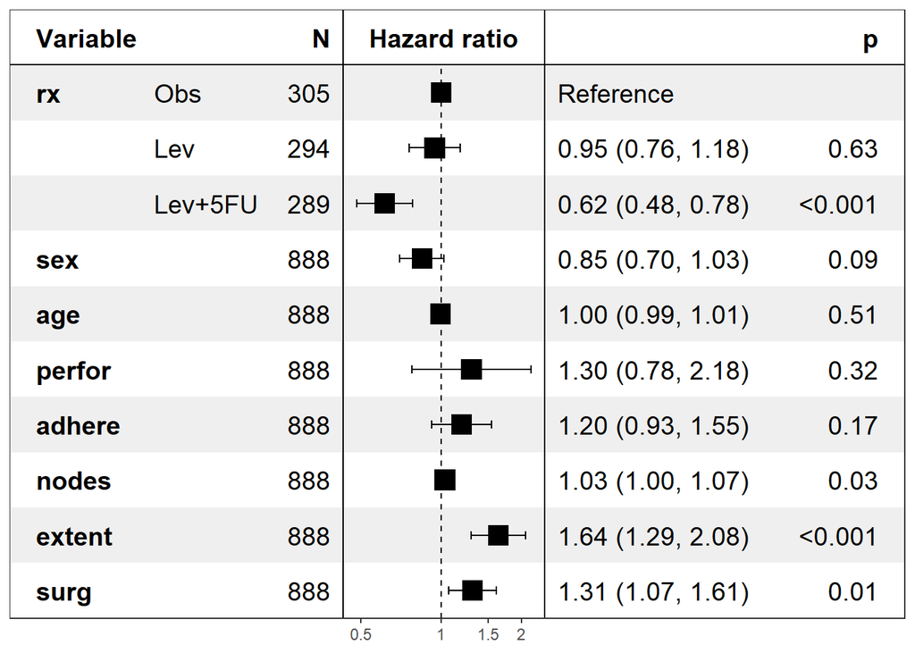

```r
library(forestmodel)

forest_model(cox_recurrence2) #plot de résultat
```

## II.Death

```r
# Modifie le nom directement sur la même ligne de code
`names<-`(parameters(cox_death2, exponentiate = TRUE), replace(names(parameters(cox_death2, exponentiate = TRUE)), names(parameters(cox_death2, exponentiate = TRUE)) == "Coefficient", "HR"))
```

```
## Parameter    |   HR |       SE |       95% CI |     z |     p
## -------------------------------------------------------------
## rx [Lev]     | 1.00 |     0.12 | [0.79, 1.27] |  0.02 | 0.986
## rx [Lev+5FU] | 0.79 |     0.10 | [0.62, 1.01] | -1.92 | 0.055
## sex          | 0.97 |     0.10 | [0.80, 1.18] | -0.30 | 0.764
## age          | 1.01 | 4.49e-03 | [1.00, 1.02] |  2.25 | 0.025
## perfor       | 1.21 |     0.34 | [0.70, 2.09] |  0.68 | 0.494
## adhere       | 1.17 |     0.16 | [0.89, 1.53] |  1.13 | 0.259
## nodes        | 1.04 |     0.02 | [1.01, 1.07] |  2.31 | 0.021
## surg         | 1.34 |     0.15 | [1.08, 1.66] |  2.69 | 0.007
```

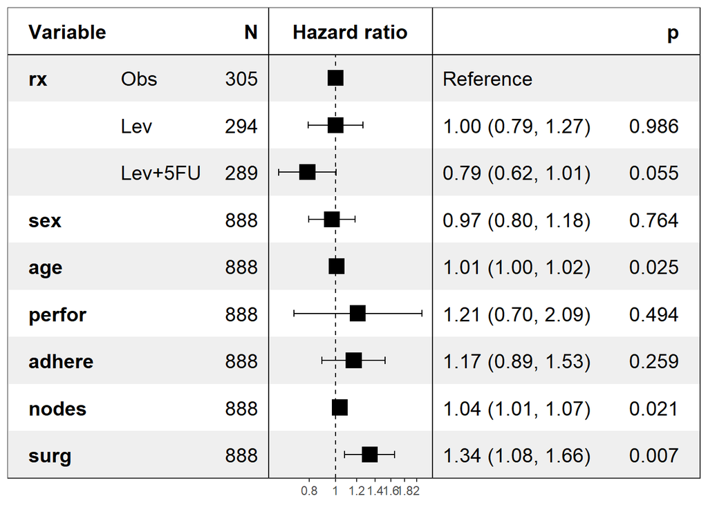

```r
library(forestmodel)

forest_model(cox_death2) #plot de résultat
```

# **Conclusion**

### **I.Recurrence**

- The combined levamisole and 5-Fluorouracil regimen was associated with a statistically significant and substantial reduction in the risk of disease recurrence, decreasing the risk by 38% compared to the observation group (HR = 0.62, 95% CI: 0.48–0.78, p < 0.001).
- In contrast, levamisole mono-therapy did not demonstrate a statistically significant effect on disease recurrence compared to observation (HR = 0.95, 95% CI: 0.76–1.18, p = 0.634).
- A greater local anatomical tumor spread was a highly significant predictor of recurrence, with each increasing level of invasion multiplying the risk of recurrence by 1.64 (HR = 1.64, 95% CI: 1.29–2.08, p < 0.001).
- A longer interval from surgical resection to study registration significantly increased the risk of disease recurrence by 31% (HR = 1.31, 95% CI: 1.07–1.61, p = 0.010).
- A higher number of positive regional lymph nodes was significantly associated with an increased risk of recurrence, showing a 3% risk increase per additional positive node detected (HR = 1.03, 95% CI: 1.00–1.07, p = 0.026).

### **II.Death**

three covariates demonstrated a statistically significant association with all-cause mortality :

- A longer interval from surgical resection to study registration (surg) was the strongest predictor of death, increasing the risk by 34% (HR = 1.34, 95% CI: 1.08–1.66, p = 0.007).
- A higher number of positive regional lymph nodes was significantly associated with an increased risk of mortality, with a 4% risk increase per additional positive node detected (HR = 1.04, 95% CI: 1.01–1.07, p = 0.021).
- Advanced age at study registration was significantly associated with an increased risk of mortality, demonstrating a 1% risk increase per year of age (HR = 1.01, 95% CI: 1.00–1.02, p = 0.025).
- The combined levamisole and 5-FU regimen showed a trend toward reduced mortality, though it did not achieve formal statistical significance (HR = 0.79, 95% CI: 0.62–1.01, p = 0.055).